# L4P1: Regressão com parlamentares

Alice Fernandes Silva

```r
atividade = read_projectdata()

atividade = atividade %>%
  na.omit(.) %>%
  filter(partido != "S/ Partido") %>%
  filter(seguidores > 0, n_proprio > 0, n_retweet > 0)  %>%
  filter(engaj_total > 0, engaj_mediano > 0)

atividade <- atividade %>%
  mutate(casa = if_else(casa == "senado", "Senado", "Câmara"))

glimpse(atividade)
```

```
## Observations: 290
## Variables: 19
## $ id_parlamentar        <chr> "204528", "178836", "160559", "204545", "2…
## $ casa                  <chr> "Câmara", "Câmara", "Câmara", "Câmara", "C…
## $ nome_eleitoral        <chr> "ADRIANA VENTURA", "ALAN RICK", "ALCEU MOR…
## $ partido               <chr> "NOVO", "DEM", "MDB", "PSL", "PT", "PSL", …
## $ UF                    <chr> "SP", "AC", "RS", "MG", "SP", "SP", "SP", …
## $ twitter               <chr> "adrianasounovo", "Alan_Rick", "Alceu_More…
## $ seguidores            <dbl> 4652, 3983, 6370, 464, 6447, 161745, 14708…
## $ segue                 <dbl> 315, 995, 434, 267, 3253, 2015, 1035, 41, …
## $ n_proprio             <dbl> 99, 49, 214, 39, 346, 830, 485, 1, 201, 29…
## $ n_retweet             <dbl> 9, 1, 30, 4, 100, 169, 204, 1, 95, 45, 50,…
## $ engaj_total           <dbl> 7090, 4286, 6852, 10231, 69348, 566011, 11…
## $ engaj_total_proprio   <dbl> 6701, 284, 2239, 186, 47967, 320063, 89409…
## $ engaj_total_retweet   <dbl> 389, 4002, 4613, 10045, 21381, 245948, 228…
## $ engaj_mediano         <dbl> 26.5, 4.0, 8.0, 4.0, 16.5, 134.0, 49.0, 1.…
## $ engaj_mediano_proprio <dbl> 22.5, 4.0, 8.0, 4.0, 12.0, 60.0, 27.0, 0.5…
## $ engaj_mediano_retweet <dbl> 0.0, 0.0, 0.0, 0.0, 0.0, 0.0, 0.0, 0.5, 0.…
## $ engaj_max             <dbl> 1031, 4002, 4227, 8171, 12335, 20348, 3643…
## $ engaj_max_proprio     <dbl> 1031, 38, 136, 14, 12335, 7271, 3643, 1, 1…
## $ engaj_max_retweet     <dbl> 99, 4002, 4227, 8171, 8623, 20348, 3302, 1…
```

### 1 — Qual a relação entre as características da atuação do parlamentar e o engajamento total que ele obtém no Twitter?

Por “características”, queremos dizer: qual a casa (senado/câmara) do parlamentar, quantas pessoas ele segue, por quantas ele é seguido, quanto ele tuíta e quanto ele retuíta.

Antes de criar o modelo iremos fazer uma análise sobre as relações lineares entre o egajamento total e cada uma das variáveis dependentes.

### Engajamento Total vs Casa

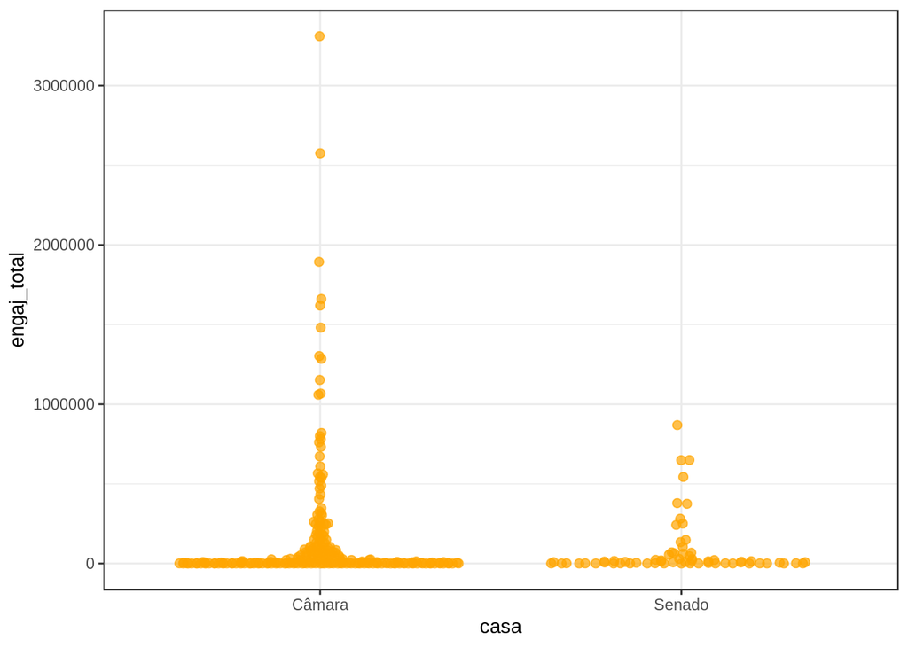

```r
atividade %>%
  ggplot(aes(x = casa, y = engaj_total)) +
  geom_quasirandom(size = 2, alpha = .7, colour = "orange")
```

Transformando os dados para a escala logarítmica:

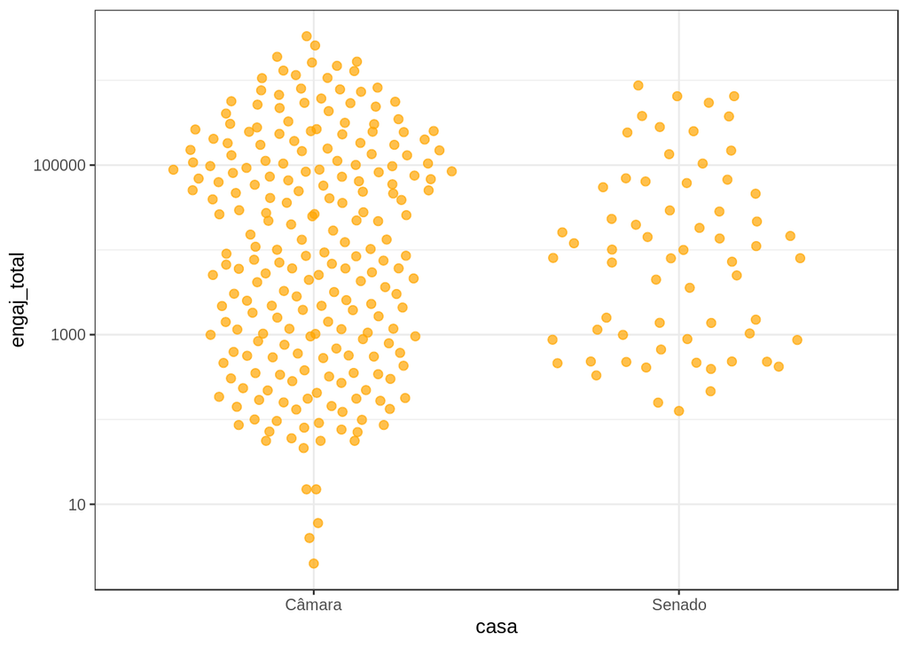

```r
atividade %>%
  ggplot(aes(x = casa, y = engaj_total)) +
  geom_quasirandom(size = 2, alpha = .7, colour = "orange") +
  scale_y_log10()
```

### Engajamento Total vs Número de Perfis Seguidos

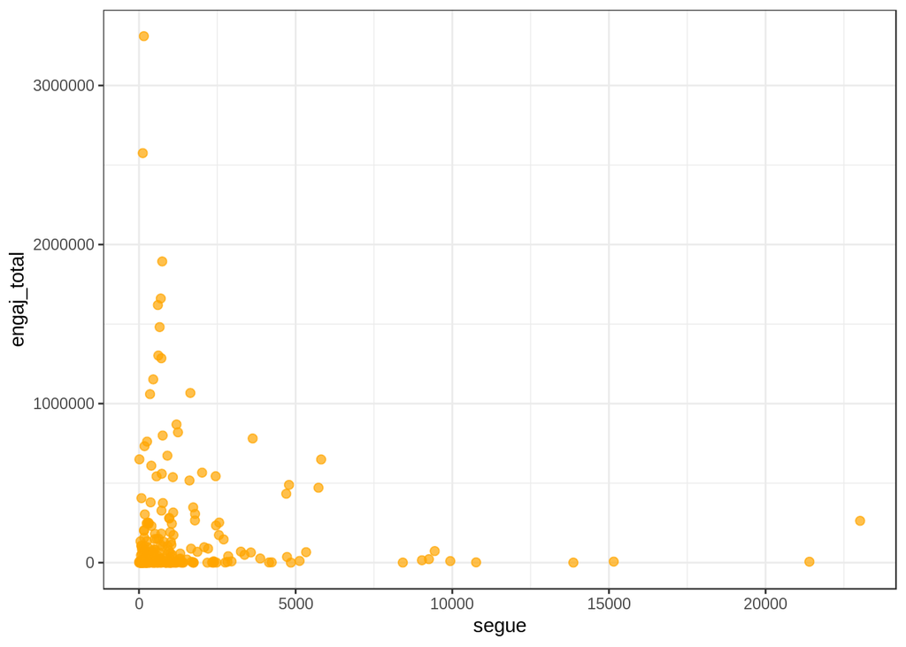

```r
atividade %>%
  ggplot(aes(x = segue, y = engaj_total)) +
  geom_point(size = 2, alpha = .7, colour = "orange")
```

Transformando os dados para a escala logarítmica:

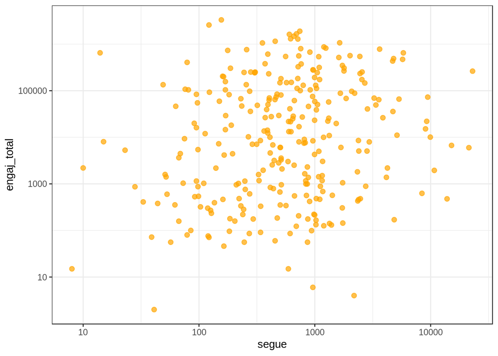

```r
atividade %>%
  ggplot(aes(x = segue, y = engaj_total)) +
  geom_point(size = 2, alpha = .7, colour = "orange") +
  scale_x_log10() +
  scale_y_log10()
```

### Engajamento Total vs Número de Seguidores

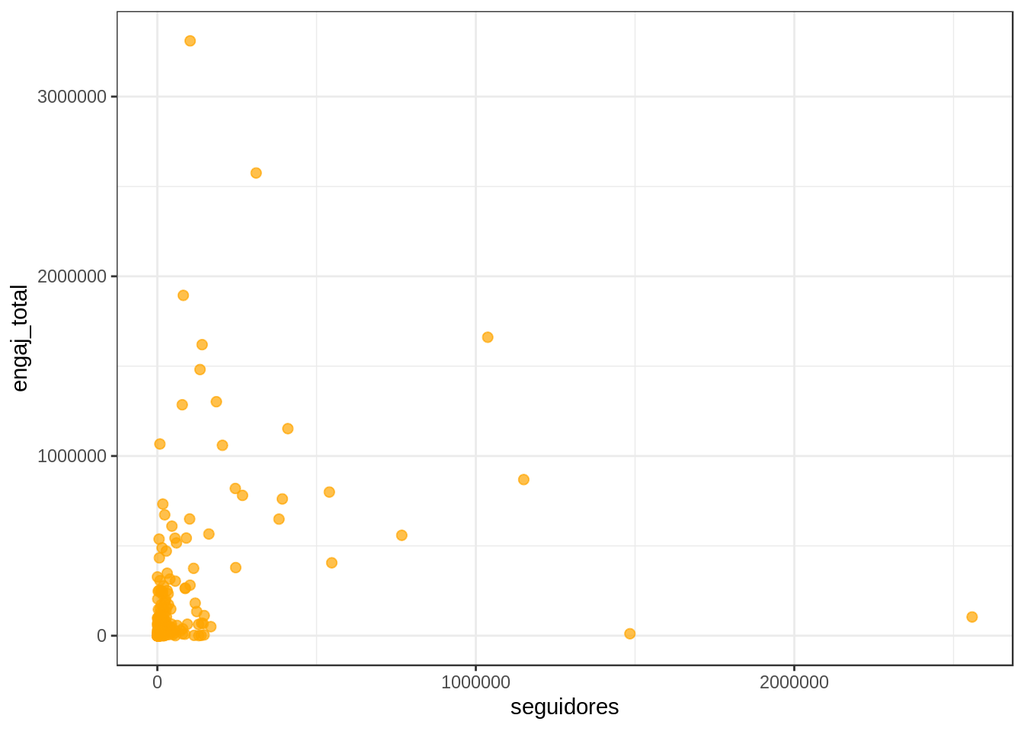

```r
atividade %>%
  ggplot(aes(x = seguidores, y = engaj_total)) +
  geom_point(size = 2, alpha = .7, colour = "orange")
```

Transformando os dados para a escala logarítmica:

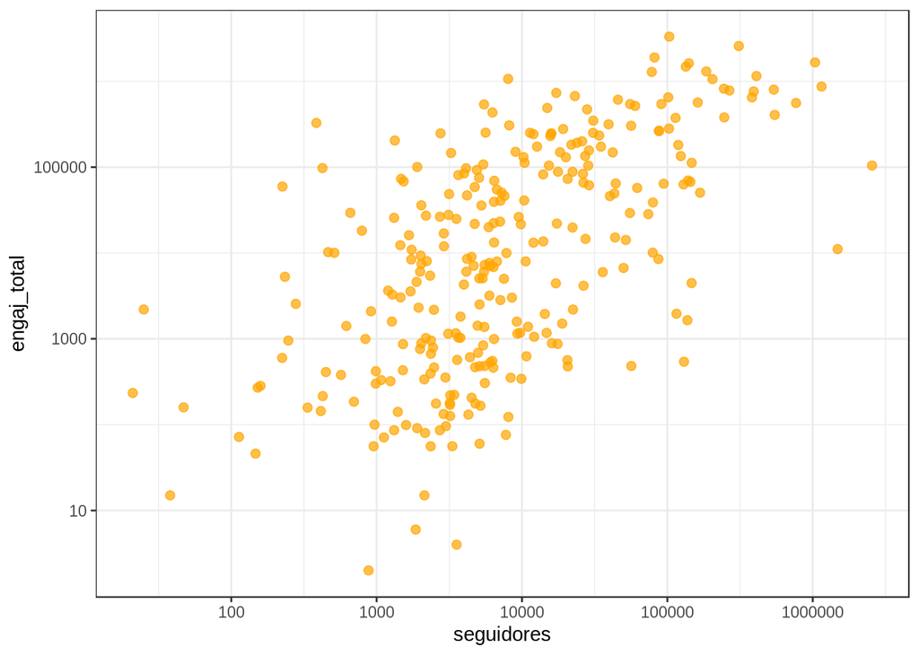

```r
atividade %>%
  ggplot(aes(x = seguidores, y = engaj_total)) +
  geom_point(size = 2, alpha = .7, colour = "orange") +
  scale_x_log10() +
  scale_y_log10()
```

### Engajamento Total vs Número de tweets

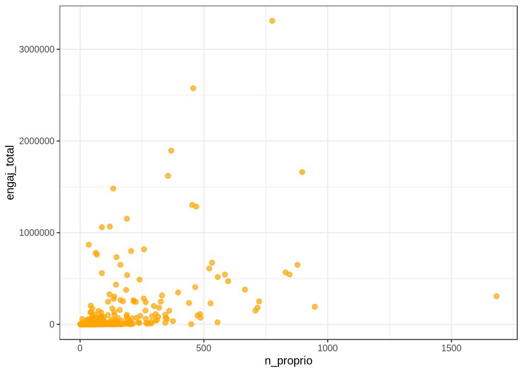

```r
atividade%>%
  ggplot(aes(x = n_proprio, y = engaj_total)) +
  geom_point(size = 2, alpha = .7, colour = "orange")
```

Transformando os dados para a escala logarítmica:

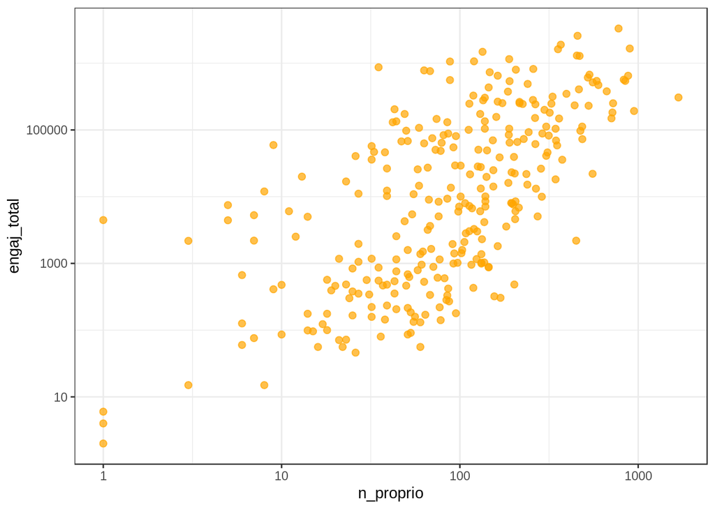

```r
atividade%>%
  ggplot(aes(x = n_proprio, y = engaj_total)) +
  geom_point(size = 2, alpha = .7, colour = "orange") +
  scale_x_log10() +
  scale_y_log10()
```

### Engajamento Total vs Número de retweets

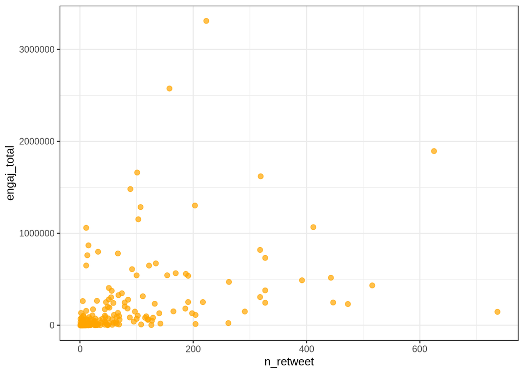

```r
atividade %>%
  ggplot(aes(x = n_retweet, y = engaj_total)) +
  geom_point(size = 2, alpha = .7, colour = "orange")
```

Transformando os dados para a escala logarítmica:

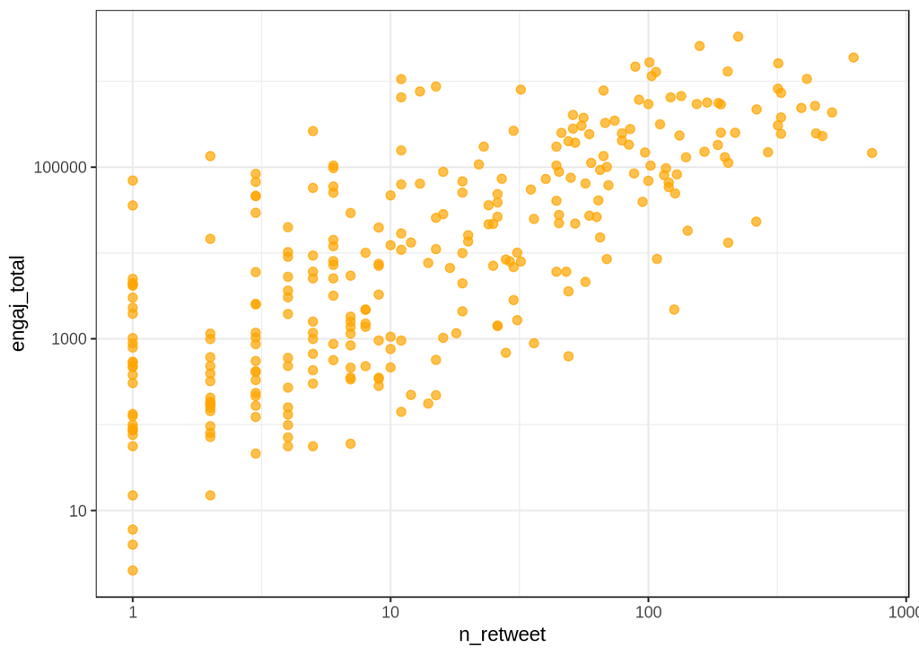

```r
atividade %>%
  ggplot(aes(x = n_retweet, y = engaj_total)) +
  geom_point(size = 2, alpha = .7, colour = "orange") +
  scale_x_log10() +
  scale_y_log10()
```

Podemos perceber que para todas as análises foi preciso transformar os dados para escala logarítmica para que fosse possível analisar as relações lineares entre as variáveis dependentes e a independente. A seguir a variávies são transformadas para que o modelo da regressão linear múltipla seja criado.

```r
atividade <- atividade %>%
  mutate(segue_log = log10(segue),
         seguidores_log = log10(seguidores),
         n_proprio_log = log10(n_proprio),
         n_retweet_log = log10(n_retweet),
         engaj_total_log = log10(engaj_total))
```

```r
modelo <- lm(engaj_total_log ~ casa + segue_log + seguidores_log + n_proprio_log + n_retweet_log,
                   data = atividade)
tidy(modelo)
```

```
## # A tibble: 6 x 5
##   term           estimate std.error statistic  p.value
##   <chr>             <dbl>     <dbl>     <dbl>    <dbl>
## 1 (Intercept)      0.532     0.255      2.08  3.80e- 2
## 2 casaSenado      -0.0680    0.103     -0.657 5.12e- 1
## 3 segue_log       -0.290     0.0753    -3.85  1.43e- 4
## 4 seguidores_log   0.565     0.0568     9.95  3.42e-20
## 5 n_proprio_log    0.530     0.0993     5.34  1.90e- 7
## 6 n_retweet_log    0.861     0.0742    11.6   1.03e-25
```

```r
glance(modelo)
```

```
## # A tibble: 1 x 11
##   r.squared adj.r.squared sigma statistic  p.value    df logLik   AIC   BIC
##       <dbl>         <dbl> <dbl>     <dbl>    <dbl> <int>  <dbl> <dbl> <dbl>
## 1     0.716         0.711 0.699      143. 1.71e-75     6  -304.  623.  649.
## # … with 2 more variables: deviance <dbl>, df.residual <int>
```

### 2. Qual a relação entre as características da atuação do parlamentar e o *engajamento mediano* que ele obtém no twitter?

Por “características”, queremos dizer: qual a casa (senado/câmara) do parlamentar, quantas pessoas ele segue, por quantas ele é seguido, quanto ele tuíta e quanto ele retuíta.

Antes de criar o modelo iremos fazer uma análise sobre as relações lineares entre o egajamento mediano e cada uma das variáveis dependentes.

### Engajamento Mediano vs Casa

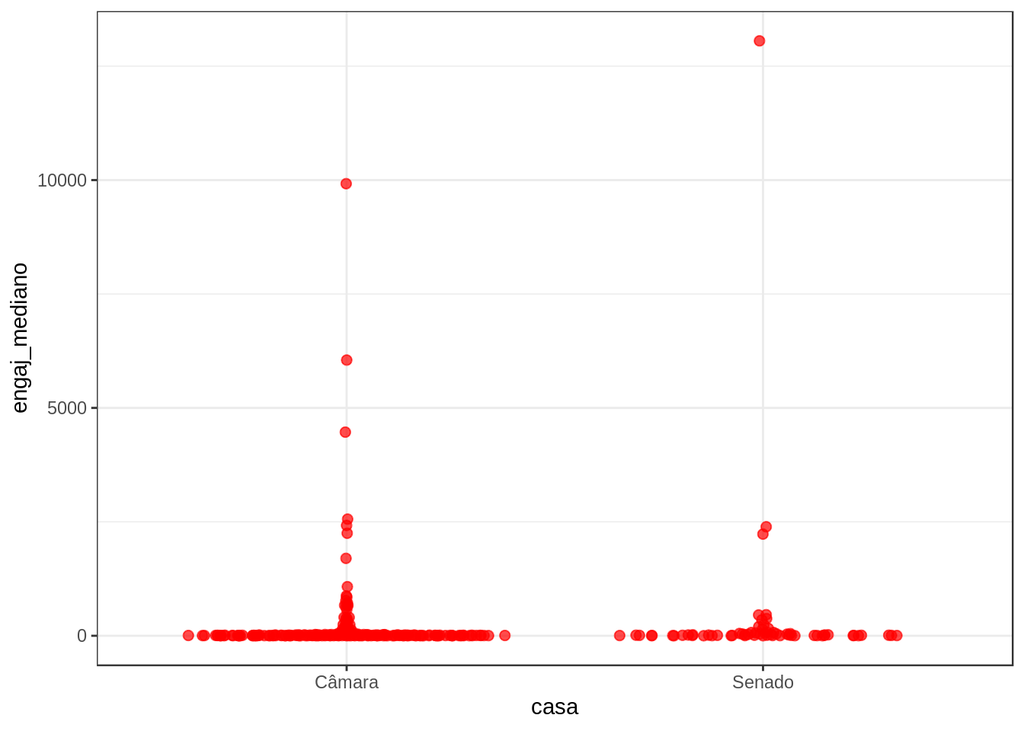

```r
atividade %>%
  ggplot(aes(x = casa, y = engaj_mediano)) +
  geom_quasirandom(size = 2, alpha = .7, colour = "red")
```

Transformando os dados para a escala logarítmica:

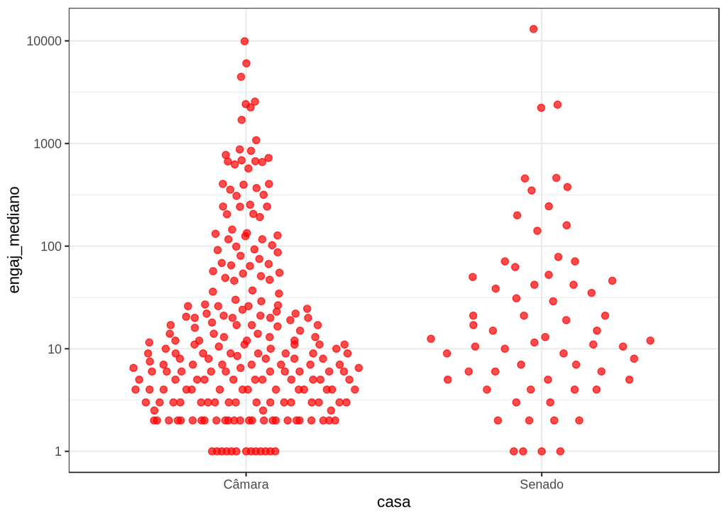

```r
atividade %>%
  ggplot(aes(x = casa, y = engaj_mediano)) +
  geom_quasirandom(size = 2, alpha = .7, colour = "red") +
  scale_y_log10()
```

### Engajamento Mediano vs Número de Perfis Seguidos

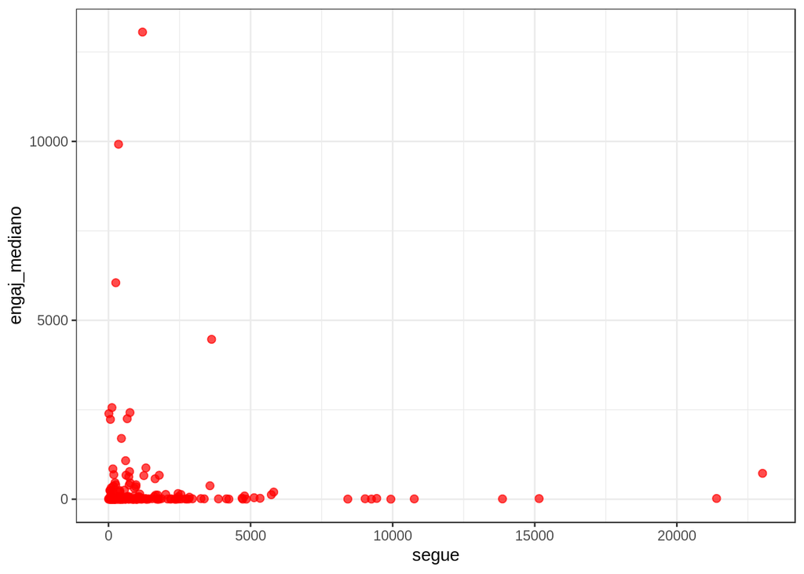

```r
atividade %>%
  ggplot(aes(x = segue, y = engaj_mediano)) +
  geom_point(size = 2, alpha = .7, colour = "red")
```

Transformando os dados para a escala logarítmica:

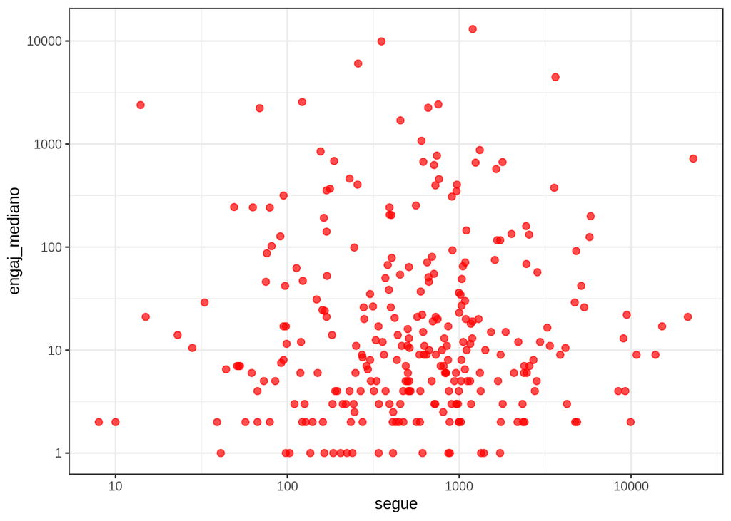

```r
atividade %>%
  ggplot(aes(x = segue, y = engaj_mediano)) +
  geom_point(size = 2, alpha = .7, colour = "red") +
  scale_x_log10() +
  scale_y_log10()
```

### Engajamento Mediano vs Número de Seguidores

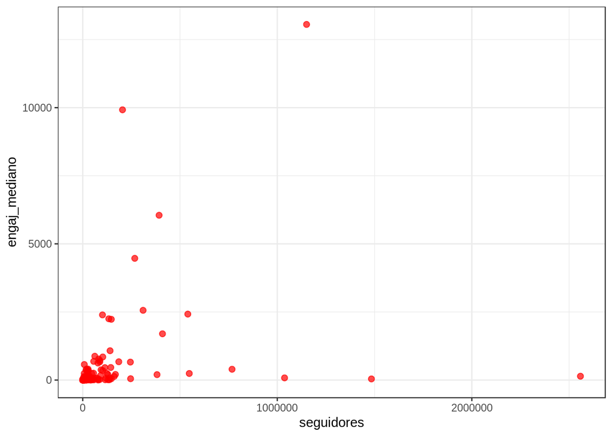

```r
atividade %>%
  ggplot(aes(x = seguidores, y = engaj_mediano)) +
  geom_point(size = 2, alpha = .7, colour = "red")
```

Transformando os dados para a escala logarítmica:

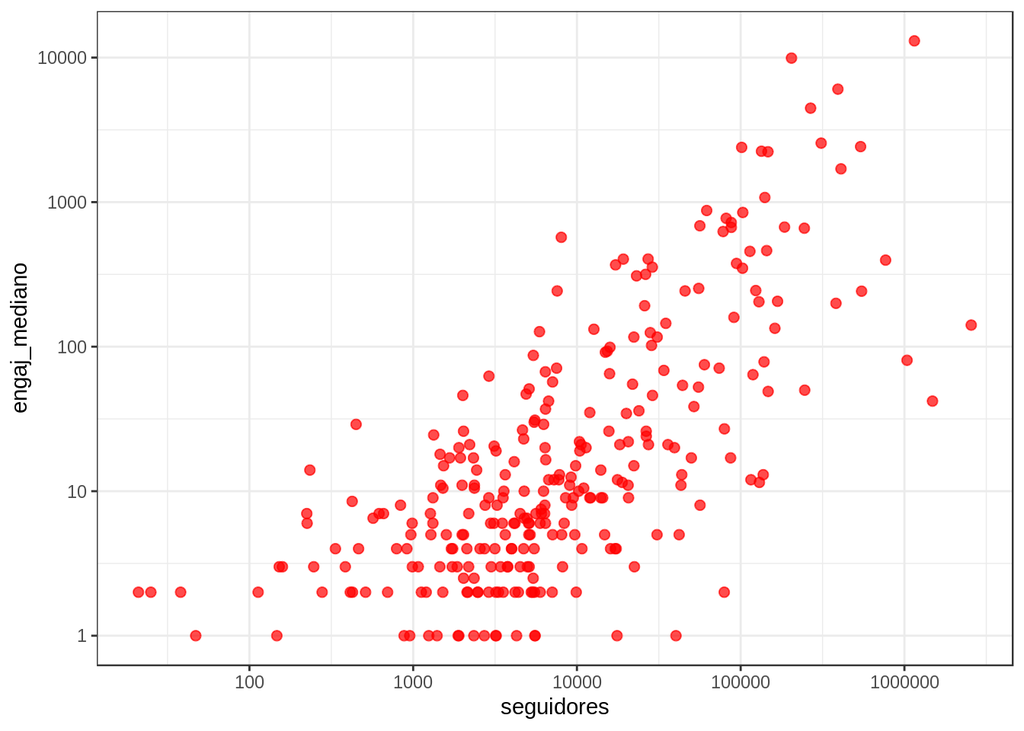

```r
atividade %>%
  ggplot(aes(x = seguidores, y = engaj_mediano)) +
  geom_point(size = 2, alpha = .7, colour = "red") +
  scale_x_log10() +
  scale_y_log10()
```

### Engajamento Mediano vs Número de tweets

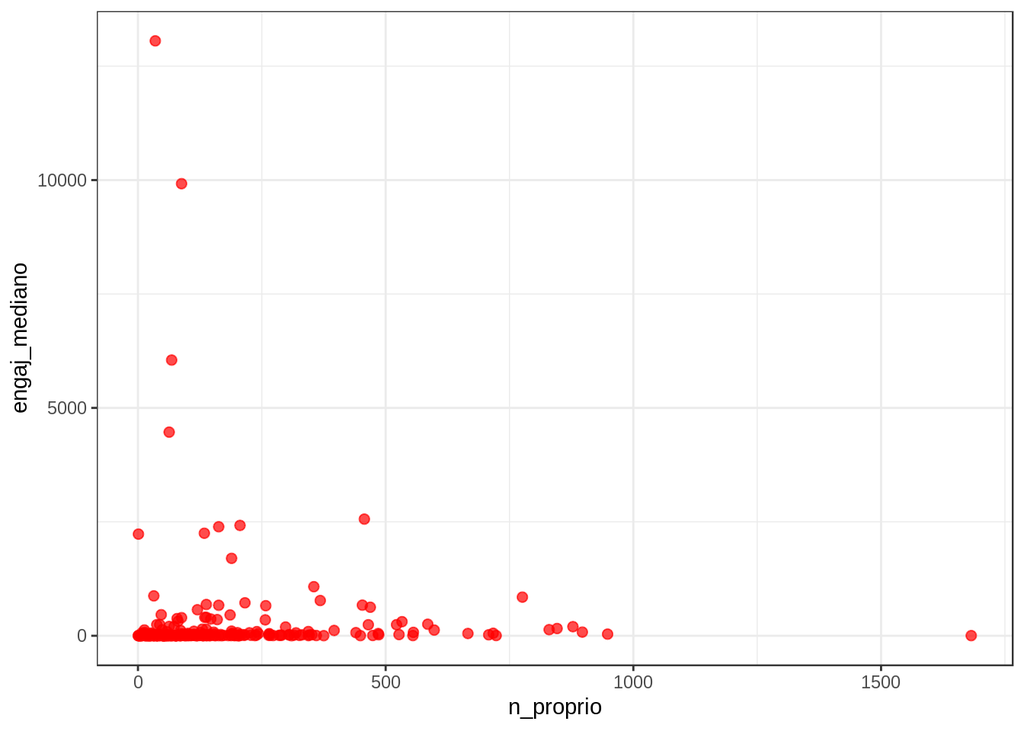

```r
atividade%>%
  ggplot(aes(x = n_proprio, y = engaj_mediano)) +
  geom_point(size = 2, alpha = .7, colour = "red")
```

Transformando os dados para a escala logarítmica:

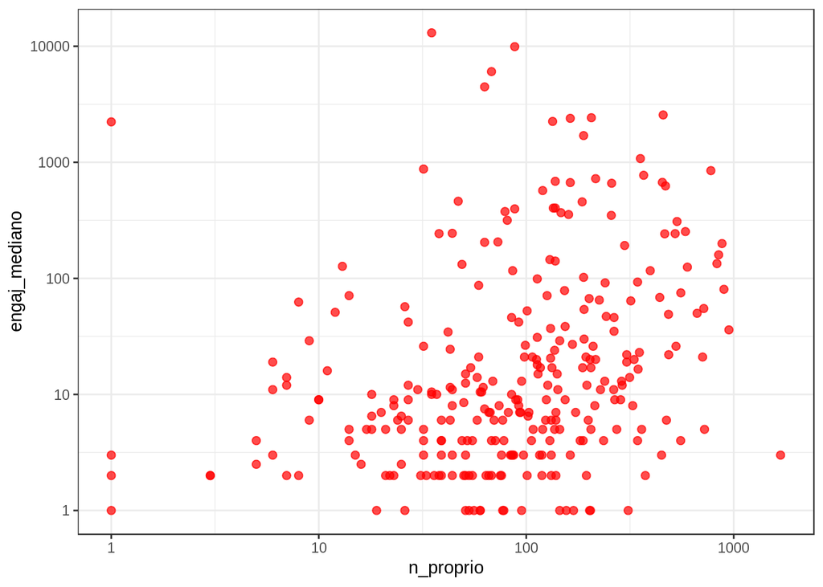

```r
atividade%>%
  ggplot(aes(x = n_proprio, y = engaj_mediano)) +
  geom_point(size = 2, alpha = .7, colour = "red") +
  scale_x_log10() +
  scale_y_log10()
```

### Engajamento Mediano vs Número de retweets

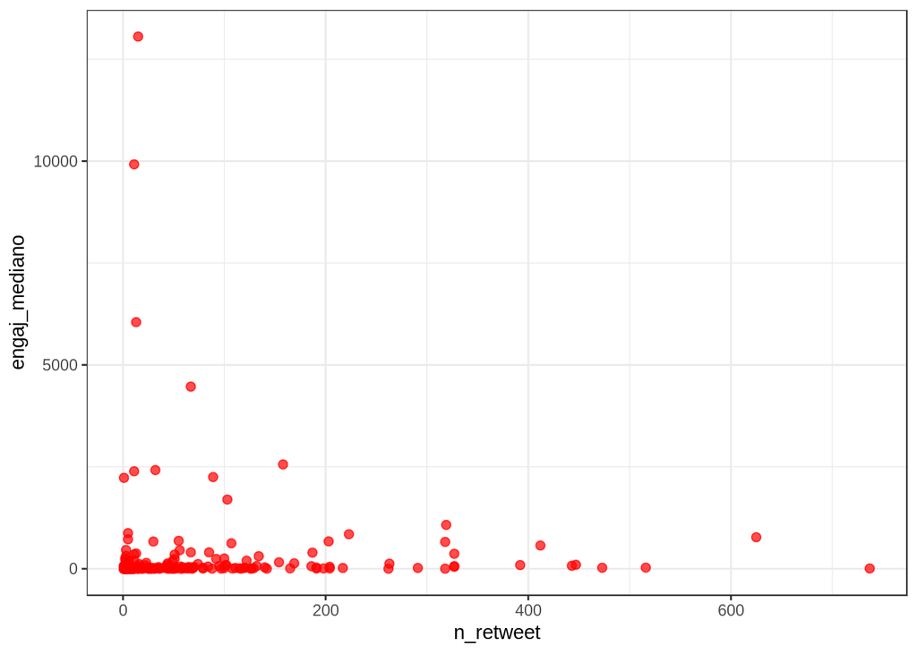

```r
atividade %>%
  ggplot(aes(x = n_retweet, y = engaj_mediano)) +
  geom_point(size = 2, alpha = .7, colour = "red")
```

Transformando os dados para a escala logarítmica:

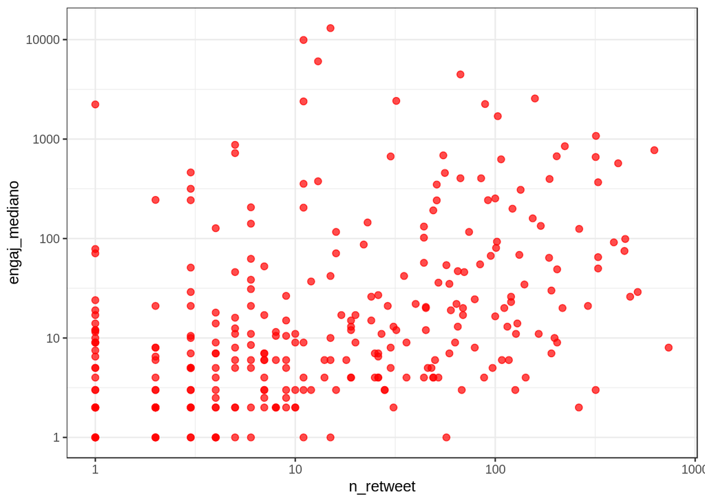

```r
atividade %>%
  ggplot(aes(x = n_retweet, y = engaj_mediano)) +
  geom_point(size = 2, alpha = .7, colour = "red") +
  scale_x_log10() +
  scale_y_log10()
```

Podemos perceber que para todas as análises foi preciso transformar os dados para escala logarítmica para que fosse possível analisar as relações lineares entre as variáveis dependentes e a independente. A seguir a variável engaj_mediano é transformada para que o modelo da regressão linear múltipla seja criado.

```r
atividade <- atividade %>%
  mutate(engaj_mediano_log = log10(engaj_mediano))
```

```r
modelo <- lm(engaj_mediano_log ~ casa + segue_log + seguidores_log + n_proprio_log + n_retweet_log,
                   data = atividade)
tidy(modelo)
```

```
## # A tibble: 6 x 5
##   term           estimate std.error statistic  p.value
##   <chr>             <dbl>     <dbl>     <dbl>    <dbl>
## 1 (Intercept)      -0.787    0.208      -3.79 1.85e- 4
## 2 casaSenado       -0.104    0.0842     -1.24 2.16e- 1
## 3 segue_log        -0.341    0.0612     -5.57 5.95e- 8
## 4 seguidores_log    0.744    0.0462     16.1  6.86e-42
## 5 n_proprio_log    -0.148    0.0808     -1.83 6.84e- 2
## 6 n_retweet_log     0.281    0.0604      4.66 4.89e- 6
```

```r
glance(modelo)
```

```
## # A tibble: 1 x 11
##   r.squared adj.r.squared sigma statistic  p.value    df logLik   AIC   BIC
##       <dbl>         <dbl> <dbl>     <dbl>    <dbl> <int>  <dbl> <dbl> <dbl>
## 1     0.573         0.565 0.569      76.2 1.98e-50     6  -245.  503.  529.
## # … with 2 more variables: deviance <dbl>, df.residual <int>
```

Com base nos resultados da regressão linear múltipla acima, as variáveis analisadas se relacionam através de um modelo com formato **log(Engaj_mediano) = - 0,10log(casaSenado) - 0,34log(segue) + 0,74log(seguidores) -0,15log(n_proprio) + 0,28log(n_retweet) - 0.78** que explica **56,53%** da variância da variável independente (R² = 0.5653095). Podemos ver que o número de seguidores é o principal fator relacionado com o engajamento mediano, ou seja, essa variável tem o maior impacto sobre o valor do engajamento mediano dos parlamentares, sendo este impacto positivo.